# Exploratory data analysis

Palmer penguins

by Arturo Frisina

# Exploring the data

## Palmer penguins dataset

Data were collected and made available by Dr. Kristen Gorman and the Palmer Station, Antarctica LTER, a member of the Long Term Ecological Research Network. The aim was to explore all the data about ecological sexual dimorphism and environmental variability within a Community of Antarctic penguins of genus *Pygoscelis* (Gorman, Williams, and Fraser 2014)

Penguins package is available at [CRAN - Package palmerpenguins](https://cran.r-project.org/web/packages/palmerpenguins/index.html) (Horst, Hill, and Gorman 2020)

```r
df = na.omit(penguins) #remove rows with NA values

kable(df) %>% kable_styling(fixed_thead = T, full_width = FALSE) %>%
  scroll_box( height = "600px")
```

| species | island | bill_length_mm | bill_depth_mm | flipper_length_mm | body_mass_g | sex | year |
| --- | --- | --- | --- | --- | --- | --- | --- |
| Adelie | Torgersen | 39.1 | 18.7 | 181 | 3750 | male | 2007 |
| Adelie | Torgersen | 39.5 | 17.4 | 186 | 3800 | female | 2007 |
| Adelie | Torgersen | 40.3 | 18.0 | 195 | 3250 | female | 2007 |
| Adelie | Torgersen | 36.7 | 19.3 | 193 | 3450 | female | 2007 |
| Adelie | Torgersen | 39.3 | 20.6 | 190 | 3650 | male | 2007 |
| Adelie | Torgersen | 38.9 | 17.8 | 181 | 3625 | female | 2007 |
| Adelie | Torgersen | 39.2 | 19.6 | 195 | 4675 | male | 2007 |
| Adelie | Torgersen | 41.1 | 17.6 | 182 | 3200 | female | 2007 |
| Adelie | Torgersen | 38.6 | 21.2 | 191 | 3800 | male | 2007 |
| Adelie | Torgersen | 34.6 | 21.1 | 198 | 4400 | male | 2007 |
| Adelie | Torgersen | 36.6 | 17.8 | 185 | 3700 | female | 2007 |
| Adelie | Torgersen | 38.7 | 19.0 | 195 | 3450 | female | 2007 |
| Adelie | Torgersen | 42.5 | 20.7 | 197 | 4500 | male | 2007 |
| Adelie | Torgersen | 34.4 | 18.4 | 184 | 3325 | female | 2007 |
| Adelie | Torgersen | 46.0 | 21.5 | 194 | 4200 | male | 2007 |
| Adelie | Biscoe | 37.8 | 18.3 | 174 | 3400 | female | 2007 |
| Adelie | Biscoe | 37.7 | 18.7 | 180 | 3600 | male | 2007 |
| Adelie | Biscoe | 35.9 | 19.2 | 189 | 3800 | female | 2007 |
| Adelie | Biscoe | 38.2 | 18.1 | 185 | 3950 | male | 2007 |
| Adelie | Biscoe | 38.8 | 17.2 | 180 | 3800 | male | 2007 |
| Adelie | Biscoe | 35.3 | 18.9 | 187 | 3800 | female | 2007 |
| Adelie | Biscoe | 40.6 | 18.6 | 183 | 3550 | male | 2007 |
| Adelie | Biscoe | 40.5 | 17.9 | 187 | 3200 | female | 2007 |
| Adelie | Biscoe | 37.9 | 18.6 | 172 | 3150 | female | 2007 |
| Adelie | Biscoe | 40.5 | 18.9 | 180 | 3950 | male | 2007 |
| Adelie | Dream | 39.5 | 16.7 | 178 | 3250 | female | 2007 |
| Adelie | Dream | 37.2 | 18.1 | 178 | 3900 | male | 2007 |
| Adelie | Dream | 39.5 | 17.8 | 188 | 3300 | female | 2007 |
| Adelie | Dream | 40.9 | 18.9 | 184 | 3900 | male | 2007 |
| Adelie | Dream | 36.4 | 17.0 | 195 | 3325 | female | 2007 |

[output cut: 303 more lines]

## Looking for simple correlations

We can try to understand for example if there’s any correlation between body mass and flipper length of all the penguins, no matter what species they belong to.

We can perform for istance a simple linear regression model between those two variables.

```r
reg = lm(df$flipper_length_mm ~ df$body_mass_g) %>% summary()
x_coeff = reg$coefficients[2] %>% round(digits= 4)
intercept = reg$coefficients[1] %>% round(digits = 0)
reg_formula = paste('y = ', intercept, '+', x_coeff, 'x', sep = '')
r_squared = reg$r.squared %>% round(digits = 3)

reg
```

```
##
## Call:
## lm(formula = df$flipper_length_mm ~ df$body_mass_g)
##
## Residuals:
##     Min      1Q  Median      3Q     Max
## -23.698  -4.983   1.056   5.101  13.933
##
## Coefficients:
##                 Estimate Std. Error t value Pr(>|t|)
## (Intercept)    1.370e+02  1.999e+00   68.56   <2e-16 ***
## df$body_mass_g 1.520e-02  4.667e-04   32.56   <2e-16 ***
## ---
## Signif. codes:  0 '***' 0.001 '**' 0.01 '*' 0.05 '.' 0.1 ' ' 1
##
## Residual standard error: 6.847 on 331 degrees of freedom
## Multiple R-squared:  0.7621, Adjusted R-squared:  0.7614
## F-statistic:  1060 on 1 and 331 DF,  p-value: < 2.2e-16
```

Just take a look at the graph below

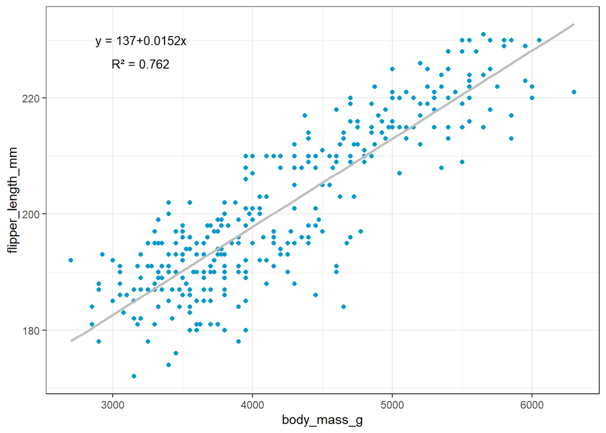

```r
ggplot(df, aes(x=body_mass_g, y=flipper_length_mm))+geom_point(color= 'deepskyblue3')+
  geom_smooth(method = 'lm', se=FALSE, color= 'grey')+
  annotate('text', x=3200, y=230, label = reg_formula, size= 3.5)+
  annotate('text', x=3200, y=226, label = paste('R² =',r_squared), size= 3.5)+
  theme_bw()
```

## Go deep…

There’s certainly a correlation between the two variables, but we can go deeper in our exploration and ask ouselves if there is any kind of difference among the species.

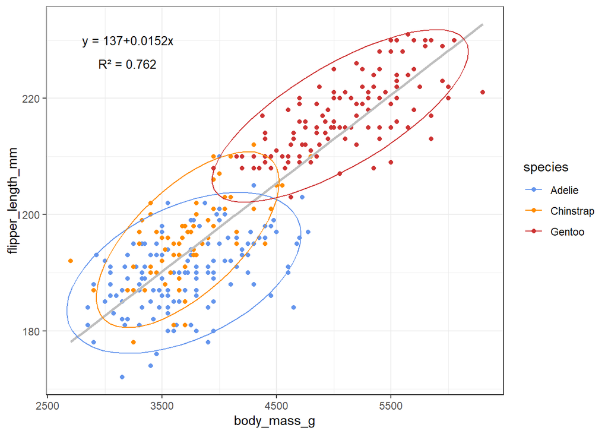

```r
ggplot(df, aes(x=body_mass_g, y=flipper_length_mm, colour=species))+
  geom_point()+
  theme_bw()+
  scale_color_manual(values=c('cornflowerblue', 'darkorange', 'brown3'))+
  geom_smooth(method = 'lm', se=FALSE, color= 'grey')+
  annotate('text', x=3200, y=230, label = reg_formula, size= 3.5)+
  annotate('text', x=3200, y=226, label = paste('R² =',r_squared), size= 3.5)+
  stat_ellipse()
```

## …and deeper

We can now add more levels of complexity (thus more information) to our data. We may further group the data acoording to another categorical variable, e.g., the sex of penguins.

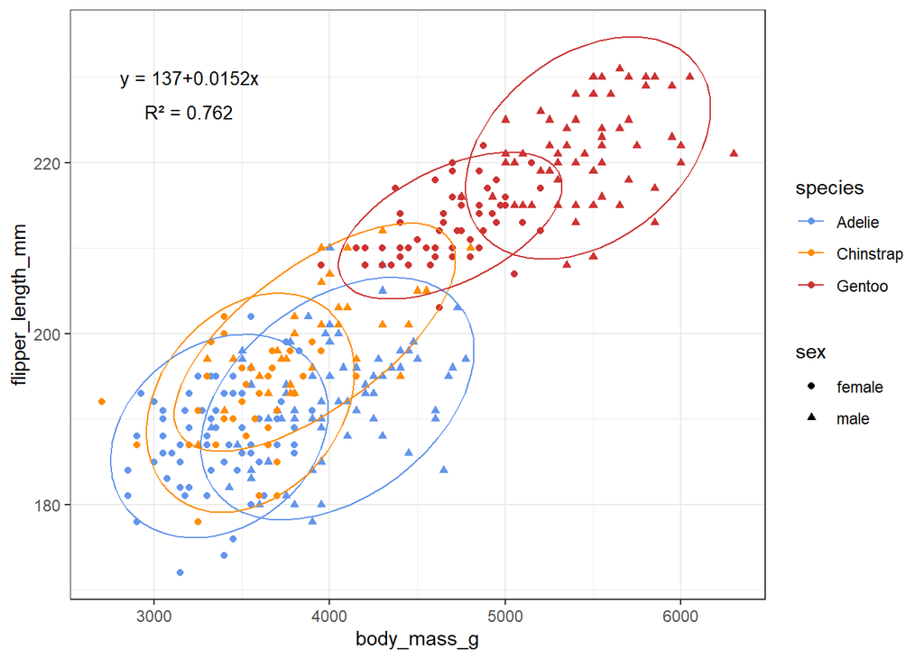

```r
ggplot(df, aes(x=body_mass_g, y=flipper_length_mm, colour=species, shape= sex))+
  geom_point()+
  theme_bw()+
  scale_color_manual(values=c('cornflowerblue', 'darkorange', 'brown3'))+
  annotate('text', x=3200, y=230, label = reg_formula, size= 3.5)+
  annotate('text', x=3200, y=226, label = paste('R² =',r_squared), size= 3.5)+
  stat_ellipse()
```

We already collect a lot of information so far: we saw a statistical correlation between body mass and flipper length and, based on our original dataset, that penguins of the *gentoo* species have greater mass and longer flippers. Males, in particular, have recorded higher values than females.

## Other correlations

Similarly we may explore the other variables looking for further information. Let’s say we want to know if there are differences regarding the size of the beak among the observed samples.

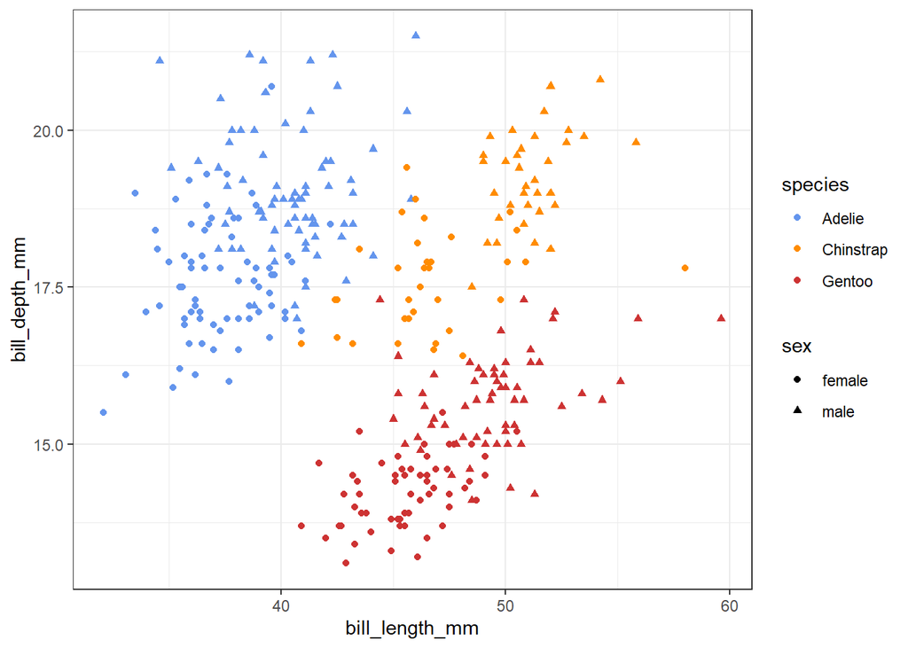

```r
ggplot(df, aes(x=bill_length_mm, y=bill_depth_mm, colour=species, shape= sex))+
  geom_point()+
  theme_bw()+
  scale_color_manual(values=c('cornflowerblue', 'darkorange', 'brown3'))
```

In this case, for these particular attributes, differences are more obvious, even if there’s not a clear correlation between the two variables.

## Too many variables!

We can keep looking for any kind of correlations. For example splitting the graphs and separate the samples according to others categorical variables.

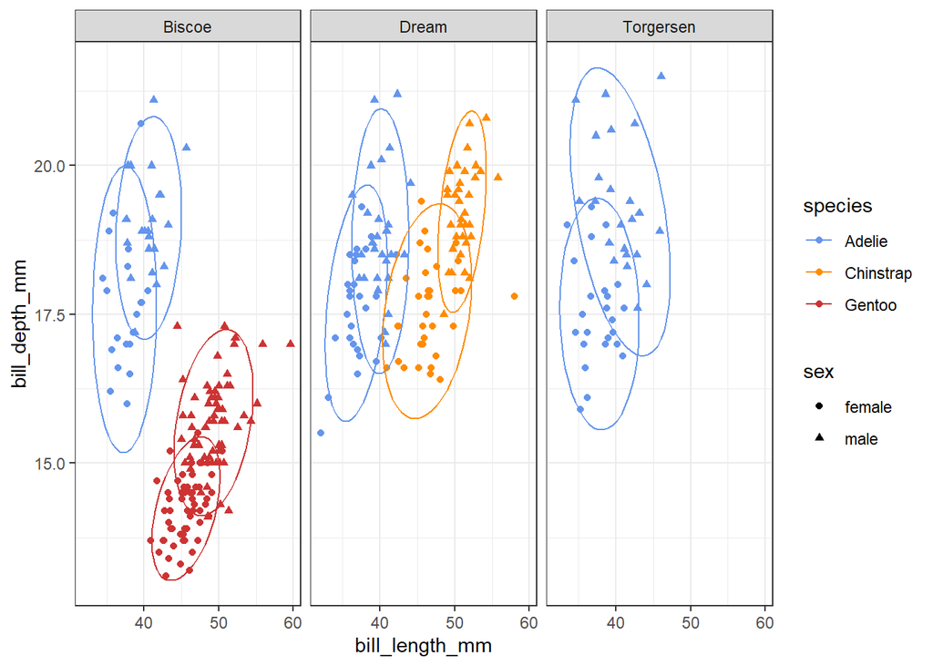

```r
ggplot(df, aes(x=bill_length_mm, y=bill_depth_mm, colour=species, shape= sex))+
  geom_point()+
  theme_bw()+
  scale_color_manual(values=c('cornflowerblue', 'darkorange', 'brown3'))+
  facet_grid(~island)+
  stat_ellipse()
```

We may wonder at this point if there is a tool of some kind with which we can perform a complete analysis of all the variables and generate a 2-dimensional plot which summarize the relationship between each samples and each variable.

# PCA

## Principal component analysis

Principal component analysis (PCA) is a popular technique for analyzing large datasets containing a high number of dimensions/features per observation, increasing the interpretability of data while preserving the maximum amount of information, and enabling the visualization of multidimensional data.

Formally, PCA is a statistical technique for reducing the dimensionality of a dataset. This is accomplished by linearly transforming the data into a new coordinate system where (most of) the variation in the data can be described with fewer dimensions than the initial data. (“Principal Component Analysis” 2022)

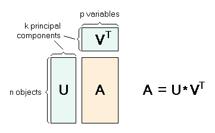

So, we want to perform PCA in order to better understand all statistical relationships among the variables, in our case all the penguins characteristics.

## Scaling data

First step is scaling data, which consist in subtracting for all values within each column their mean and then divide by their standard deviation

$$X^*_{i,j} = \frac{X_{i,j} - \overline{X_i}}{S_{X_i}}$$

This operation it’s called **autoscaling** and allows you to have all the data in the same order of magnitude.

```r
df_scaled = df[,3:6] %>% scale() %>% data.frame()

kable(df_scaled) %>% kable_styling(fixed_thead = T, full_width = FALSE) %>%
  scroll_box( height = "500px")
```

| bill_length_mm | bill_depth_mm | flipper_length_mm | body_mass_g |
| --- | --- | --- | --- |
| -0.8946955 | 0.7795590 | -1.4246077 | -0.5676206 |
| -0.8215515 | 0.1194043 | -1.0678666 | -0.5055254 |
| -0.6752636 | 0.4240910 | -0.4257325 | -1.1885721 |
| -1.3335592 | 1.0842457 | -0.5684290 | -0.9401915 |
| -0.8581235 | 1.7444004 | -0.7824736 | -0.6918109 |
| -0.9312674 | 0.3225288 | -1.4246077 | -0.7228585 |
| -0.8764095 | 1.2365891 | -0.4257325 | 0.5811398 |
| -0.5289757 | 0.2209665 | -1.3532595 | -1.2506673 |
| -0.9861254 | 2.0490872 | -0.7111254 | -0.5055254 |
| -1.7175649 | 1.9983060 | -0.2116878 | 0.2396164 |
| -1.3518452 | 0.3225288 | -1.1392148 | -0.6297157 |
| -0.9678394 | 0.9319023 | -0.4257325 | -0.9401915 |
| -0.2729719 | 1.7951815 | -0.2830361 | 0.3638067 |
| -1.7541369 | 0.6272156 | -1.2105630 | -1.0954294 |
| 0.3670377 | 2.2014306 | -0.4970807 | -0.0087642 |
| -1.1324133 | 0.5764344 | -1.9240453 | -1.0022867 |
| -1.1506993 | 0.7795590 | -1.4959559 | -0.7539060 |
| -1.4798471 | 1.0334646 | -0.8538219 | -0.5055254 |
| -1.0592694 | 0.4748722 | -1.1392148 | -0.3192400 |
| -0.9495534 | 0.0178420 | -1.4959559 | -0.5055254 |
| -1.5895630 | 0.8811212 | -0.9965183 | -0.5055254 |
| -0.6204057 | 0.7287778 | -1.2819112 | -0.8160012 |
| -0.6386916 | 0.3733099 | -0.9965183 | -1.2506673 |
| -1.1141273 | 0.7287778 | -2.0667417 | -1.3127624 |
| -0.6386916 | 0.8811212 | -1.4959559 | -0.3192400 |
| -0.8215515 | -0.2360636 | -1.6386524 | -1.1885721 |
| -1.2421292 | 0.4748722 | -1.6386524 | -0.3813351 |
| -0.8215515 | 0.3225288 | -0.9251701 | -1.1264770 |
| -0.5655477 | 0.8811212 | -1.2105630 | -0.3813351 |
| -1.3884171 | -0.0837202 | -0.4257325 | -1.0954294 |

[output cut: 303 more lines]

## Correlation matrix

Now we can generate the correlation matrix which tell us the degree of correlation between each pair of variables.

```r
df_cor = cor(df_scaled)
kable(df_cor) %>% kable_styling(full_width = FALSE)
```

|  | bill_length_mm | bill_depth_mm | flipper_length_mm | body_mass_g |
| --- | --- | --- | --- | --- |
| bill_length_mm | 1.0000000 | -0.2286256 | 0.6530956 | 0.5894511 |
| bill_depth_mm | -0.2286256 | 1.0000000 | -0.5777917 | -0.4720157 |
| flipper_length_mm | 0.6530956 | -0.5777917 | 1.0000000 | 0.8729789 |
| body_mass_g | 0.5894511 | -0.4720157 | 0.8729789 | 1.0000000 |

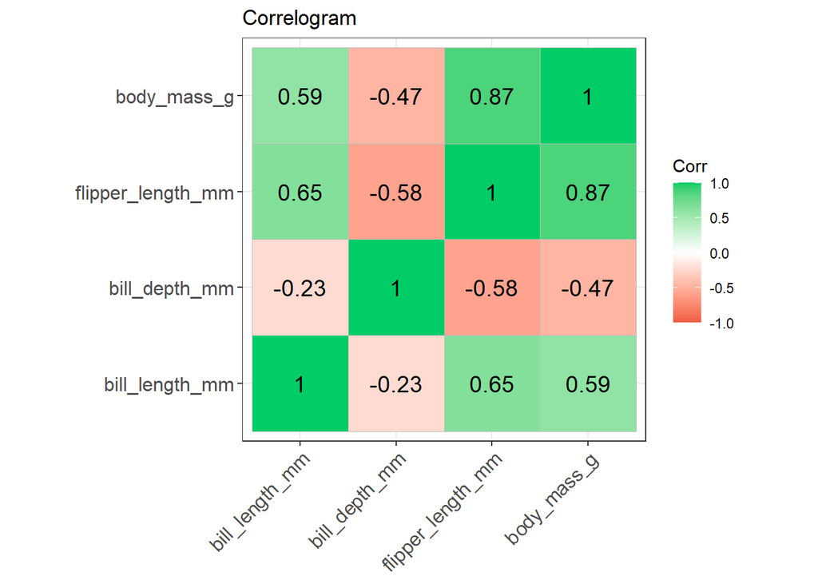

```r
library(ggcorrplot)

ggcorrplot(df_cor,
           type = 'full',
           method = 'square',
           lab = TRUE,
           lab_size = 5,
           colors = c("tomato2", "white", "springgreen3"),
           title="Correlogram",
           ggtheme=theme_bw)
```

General formula for correlation between two variables $X$ and $Y$ is

$$corr(X,Y) = \frac{cov(X,Y)}{\sigma_x \sigma_y}$$

## Eigenvalues and eigenvectors

We can now calculate the *eigenvalues* and *eigenvectors* of this matrix.

Between a generic matrix ${\bf C}$, a scalar $\lambda$ (eigenvalue) and a vector ${\bf v}$ (eigenvector) exists the following relationship

$${\bf Cv} = {\bf \lambda v}$$

For our correlation matrix eigenvalues are

```r
eig = eigen(df_cor)
eig$values
```

```
## [1] 2.7453557 0.7781172 0.3686425 0.1078846
```

You may notice that the sum of these eigenvalues is equal to the number of variables of our original data matrix.

Each of them rapresents the amount of variance explained by every principal component.

## Scree plot

We can also express them as a percentage of total variance and put them in a graph also known as *scree plot*.

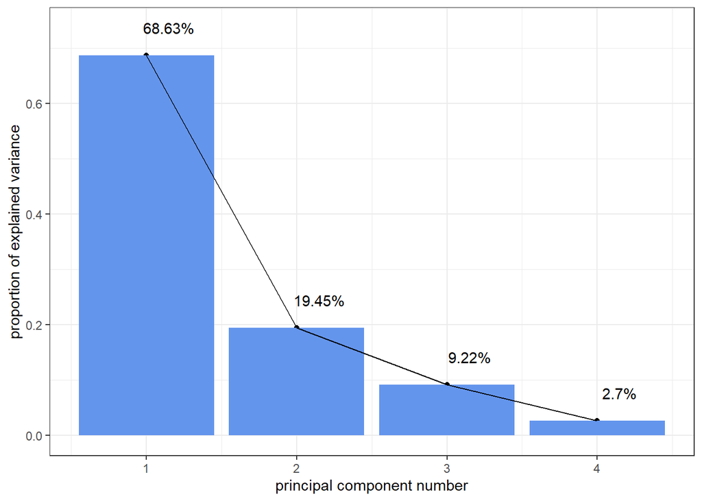

```r
values_prc = round((eig$values/sum(eig$values)), digits = 4)

pc = prcomp(df_scaled)

ggscreeplot(pc)+
  geom_col(fill = 'cornflowerblue') +
  geom_line()+
  theme_bw()+
  geom_text(label=(paste0(values_prc*100,'%')), nudge_y = 0.05, nudge_x = 0.15)
```

```r
pc = pca(df_scaled)
```

Looking at this chart it’s clear that most of the total variance is explained by the first principal component (the 68.63%).

We can therefore represent our original data using a 2-dimensional graph with PC1 and PC2 as x and Y axis.

## Loading vectors

Loadings are the eigenvectors of the correlation matrix and they are normalized, which means that for a $p$ loading, for $m$ variables and $a$ principal component:

$$\sum_{i=1}^m p_{a,j}^2 = 1$$

For our dataset loading vectors will be

```r
load1 = eig$vectors[,1]
load2 = eig$vectors[,2]
load_df = data.frame(load1,load2, row.names = colnames(df[3:6]))

kable(load_df) %>% kable_styling(full_width = FALSE)
```

|  | load1 | load2 |
| --- | --- | --- |
| bill_length_mm | 0.4537532 | -0.6001949 |
| bill_depth_mm | -0.3990472 | -0.7961695 |
| flipper_length_mm | 0.5768250 | -0.0057882 |
| body_mass_g | 0.5496747 | -0.0764637 |

## Score vectors

We can project the original observation values (objects) onto the principal components and call them *scores*. To do this properly we have to multiply each loading vectors component for every value in the original data matrix.

The loadings can be understood then as the weights for each original variable when calculating the principal component.

In our dataset, the first two score vectors are

```r
score_pc1 = as.matrix(df_scaled) %*% load1
score_pc2 = as.matrix(df_scaled) %*% load2

score = data.frame(score_pc1, score_pc2)

kable(score) %>% kable_styling(full_width = FALSE, fixed_thead = TRUE) %>% scroll_box(height = '500px')
```

| score_pc1 | score_pc2 |
| --- | --- |
| -1.8508078 | -0.0320212 |
| -1.3142762 | 0.4428603 |
| -1.3745366 | 0.1609882 |
| -1.8824555 | 0.0123327 |
| -1.9170957 | -0.8163696 |
| -1.7703561 | 0.3656727 |
| -0.8172664 | -0.5004899 |
| -1.7962546 | 0.2450252 |
| -1.9532096 | -0.9967828 |
| -1.5671647 | -0.5772133 |
| -1.7453746 | 0.6093273 |
| -1.5734059 | -0.0867052 |
| -0.8035110 | -1.2916122 |
| -2.3466466 | 0.6442216 |
| -1.0034763 | -1.9694587 |
| -2.4046297 | 0.3085044 |
| -2.1105221 | 0.1362880 |
| -1.8542668 | 0.1089801 |
| -1.5027490 | 0.2886935 |
| -1.5787620 | 0.6030250 |
| -1.9255694 | 0.2969481 |
| -1.7603015 | -0.1380520 |
| -1.7010535 | 0.1875201 |
| -2.7100962 | 0.2008041 |
| -1.6798002 | -0.2851133 |
| -1.8771248 | 0.7814051 |
| -1.9079424 | 0.4060840 |
| -1.6543430 | 0.3277930 |
| -1.5161213 | -0.3259178 |
| -1.4442933 | 0.9862011 |

[output cut: 303 more lines]

## Score plot

Let’s have a look to what happens when we now plot these values onto a scatter plot

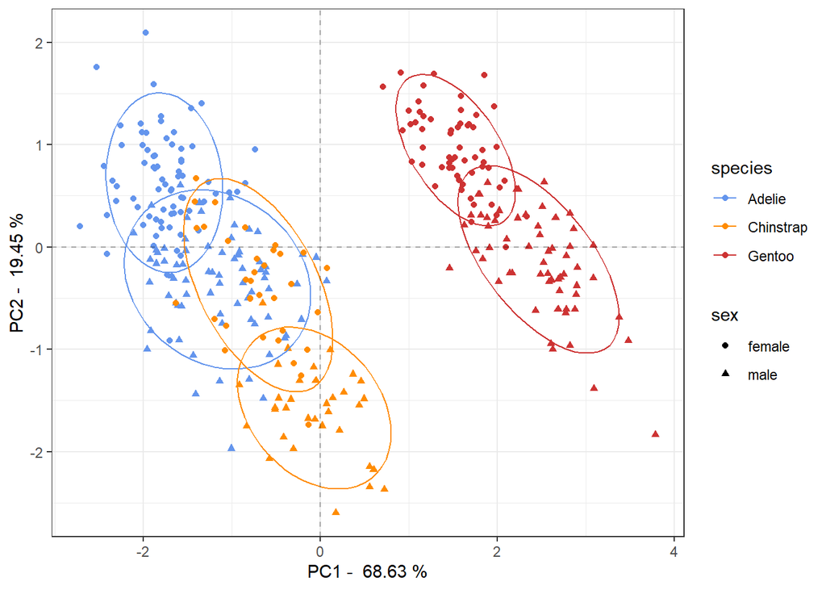

```r
score_df = data.frame(df[,c(1,2,7,8)], score)

ggplot(data=score_df, aes(score_pc1, score_pc2, color=species, shape=sex))+
  geom_point()+
  theme_bw()+
  stat_ellipse(level = 0.9)+
  xlab(paste('PC1 - ', values_prc[1]*100, '%'))+
  ylab(paste('PC2 - ', values_prc[2]*100, '%'))+
  scale_color_manual(values=c('cornflowerblue', 'darkorange', 'brown3'))+
  geom_vline(xintercept= 0, linetype="dashed", alpha = 0.3)+
  geom_hline(yintercept= 0, linetype="dashed", alpha = 0.3)
```

It’s immediately clear how the data are grouped into two major **clusters** and penguins of species *Gentoo* seem to have different characteristics than the others.

A similar result could have been achieved through a classical *cluster analysis*. With PCA however we’re able to see which variables are most responsible for the variation.

## Loading plot

Let’s now take the first two loading vectors we calculate before and plot them one against the other.

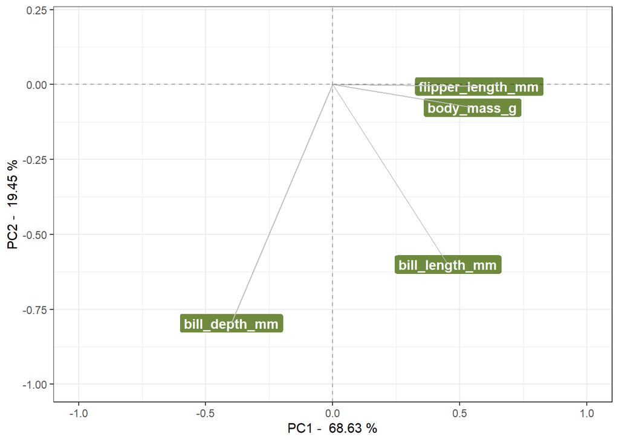

```r
ggplot(load_df, aes(load1, load2))+
  geom_point()+
  theme_bw()+
  geom_label(label= rownames(load_df),color='white', fill= 'darkolivegreen4', fontface = 'bold')+
  xlim(-1,1)+ylim(-1,0.2)+
  xlab(paste('PC1 - ', values_prc[1]*100, '%'))+
  ylab(paste('PC2 - ', values_prc[2]*100, '%'))+
  geom_segment(xend=0, yend=0, color= 'grey')+
  geom_vline(xintercept= 0, linetype="dashed", alpha = 0.3)+
  geom_hline(yintercept= 0, linetype="dashed", alpha = 0.3)
```

This graph show us the direction of each variable along the principal components.

Vectors of `flipper_length_mm` and `body_mass_g` are almost parralel to each other, this means they are highly correlated (as we’re already seen before with linear regression).

On the other hand `bill_depth_mm` and `bill_length_mm` are located on the opposite sides of the first principal component (the x axis). This suggest there is a weak negative correlation between them.